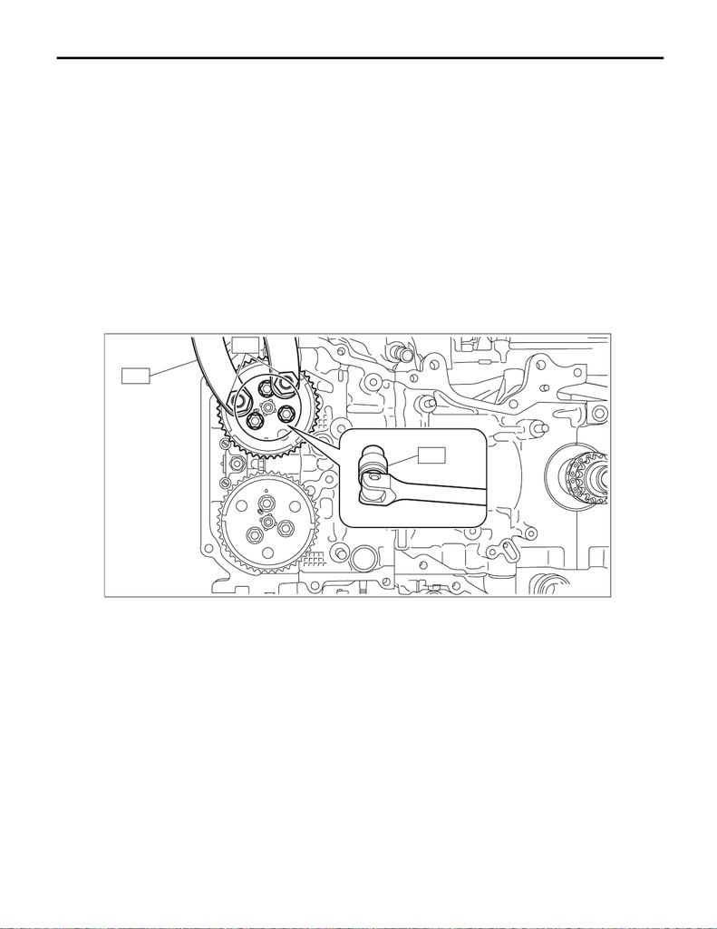

ME(w/o STI)-141

Cam Sprocket

MECHANICAL

16.Cam Sprocket

A: REMOVAL

1. CAM SPROCKET RH

NOTE:

When replacing a single part, perform the work with the engine assembly installed to body.

• Intake cam sprocket RH

1) Remove the chain cover. <Ref. to ME(w/o STI)-93, REMOVAL, Chain Cover.>

2) Remove the timing chain RH. <Ref. to ME(w/o STI)-116, TIMING CHAIN RH, REMOVAL, Timing Chain

Assembly.>

3) Hold the intake cam sprocket RH using the ST1 and ST2, and remove the bolts using the ST3.

CAUTION:

Perform the operation carefully since the ST comes off easily.

ST1 18355AA000 PULLEY WRENCH

ST2 18334AA020 PULLEY WRENCH PIN SET

ST3 18270KA010 SOCKET

4) Remove the intake cam sprocket RH.

ME-07978

ST1

ST2

ST3

15WRX_STI_US_EN.book 141 ページ ２０１５年２月１３日 金曜日 午前１１時２０分

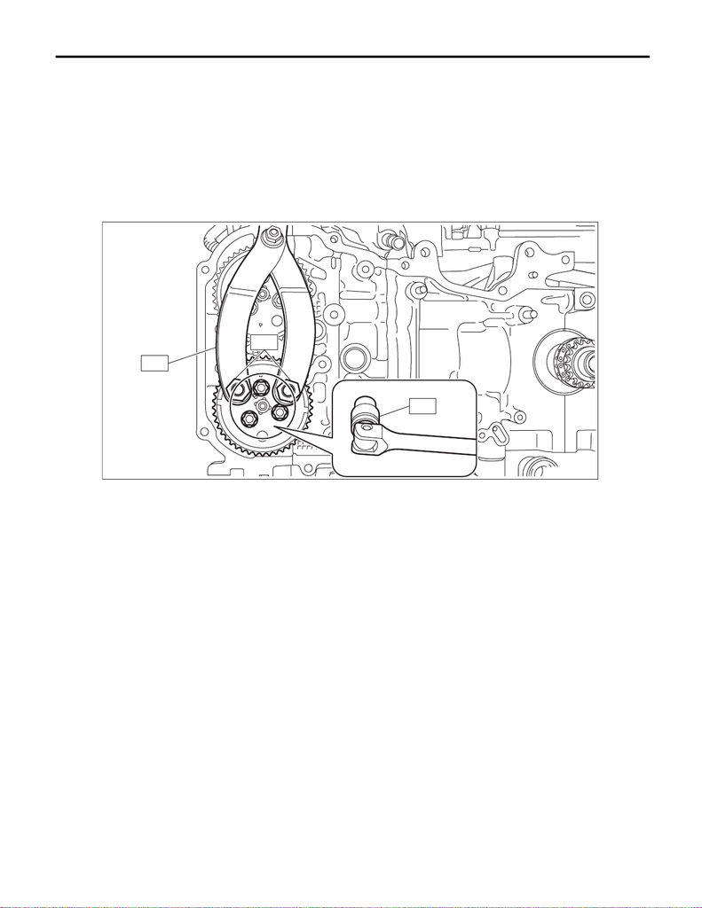

ME(w/o STI)-142

Cam Sprocket

MECHANICAL

• Exhaust cam sprocket RH

1) Remove the chain cover. <Ref. to ME(w/o STI)-93, REMOVAL, Chain Cover.>

2) Remove the timing chain RH. <Ref. to ME(w/o STI)-116, TIMING CHAIN RH, REMOVAL, Timing Chain

Assembly.>

3) Hold the exhaust cam sprocket RH using the ST1 and ST2, and remove the bolts using the ST3.

CAUTION:

Perform the operation carefully since the ST comes off easily.

ST1 18355AA000 PULLEY WRENCH

ST2 18334AA020 PULLEY WRENCH PIN SET

ST3 18270KA010 SOCKET

4) Remove the exhaust cam sprocket RH.

2. CAM SPROCKET LH

NOTE:

When replacing a single part, perform the work with the engine assembly installed to body.

• Intake cam sprocket LH

1) Remove the chain cover. <Ref. to ME(w/o STI)-93, REMOVAL, Chain Cover.>

2) Remove the timing chain LH. <Ref. to ME(w/o STI)-119, TIMING CHAIN LH, REMOVAL, Timing Chain

Assembly.>

3) Hold the intake cam sprocket LH using the ST1 and ST2, and remove the bolts using the ST3.

ME-07979

ST2

ST3

ST1

15WRX_STI_US_EN.book 142 ページ ２０１５年２月１３日 金曜日 午前１１時２０分

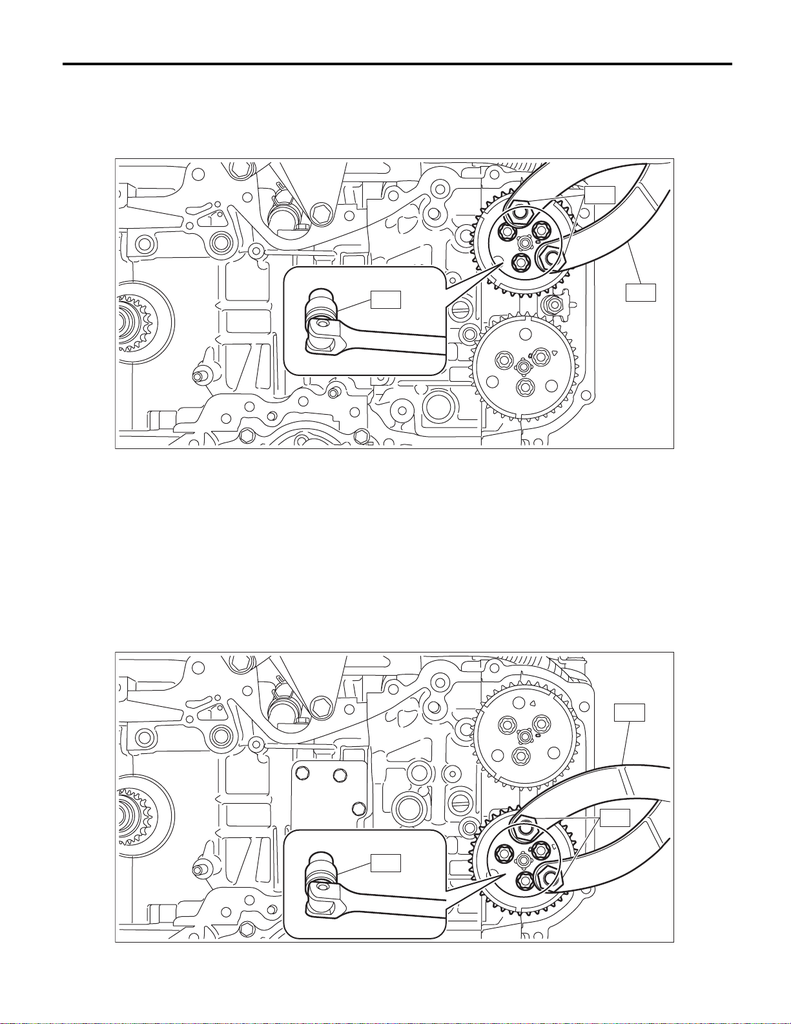

ME(w/o STI)-143

Cam Sprocket

MECHANICAL

CAUTION:

Perform the operation carefully since the ST comes off easily.

ST1 18355AA000 PULLEY WRENCH

ST2 18334AA020 PULLEY WRENCH PIN SET

ST3 18270KA010 SOCKET

4) Remove the intake cam sprocket LH.

• Exhaust cam sprocket LH

1) Remove the chain cover. <Ref. to ME(w/o STI)-93, REMOVAL, Chain Cover.>

2) Remove the timing chain LH. <Ref. to ME(w/o STI)-119, TIMING CHAIN LH, REMOVAL, Timing Chain

Assembly.>

3) Hold the exhaust cam sprocket LH using the ST1 and ST2, and remove the bolts using the ST3.

CAUTION:

Perform the operation carefully since the ST comes off easily.

ST1 18355AA000 PULLEY WRENCH

ST2 18334AA020 PULLEY WRENCH PIN SET

ST3 18270KA010 SOCKET

4) Remove the exhaust cam sprocket LH.

ME-07980

ST1

ST2

ST3

ME-07981

ST1

ST2

ST3

15WRX_STI_US_EN.book 143 ページ ２０１５年２月１３日 金曜日 午前１１時２０分

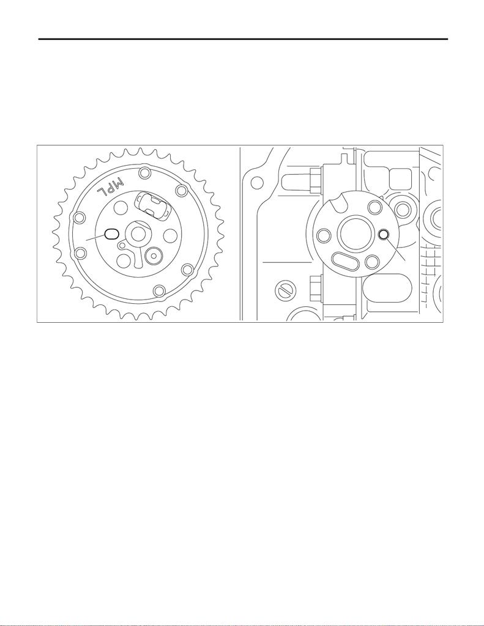

ME(w/o STI)-144

Cam Sprocket

MECHANICAL

B: INSTALLATION

1. CAM SPROCKET RH

• Intake cam sprocket RH

1) Install the intake cam sprocket RH by aligning the knock hole (A) of intake cam sprocket RH and the knock

pin (B) of intake camshaft RH.

NOTE:

Before installation, check that there is no foreign matter on the intake cam sprocket RH and intake camshaft

RH.

ME-06665

(A)

(B)

15WRX_STI_US_EN.book 144 ページ ２０１５年２月１３日 金曜日 午前１１時２０分

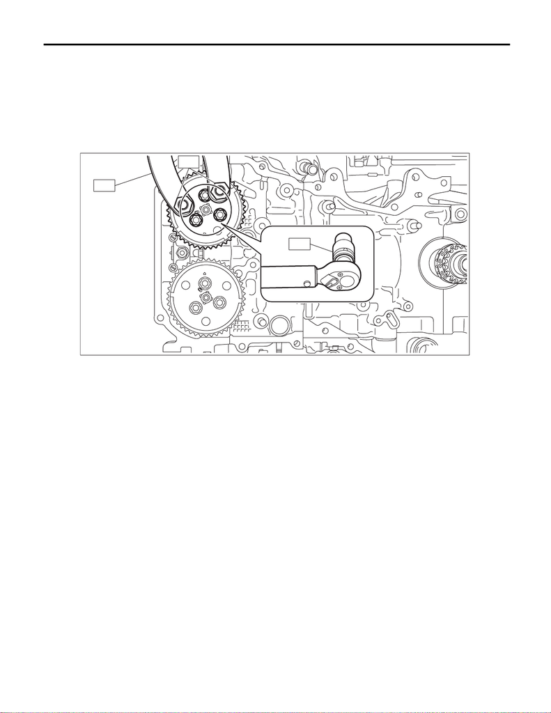

ME(w/o STI)-145

Cam Sprocket

MECHANICAL

2) Hold the intake cam sprocket RH using the ST1 and ST2, and install the bolts using the ST3.

CAUTION:

Perform the operation carefully since the ST comes off easily.

ST1 18355AA000 PULLEY WRENCH

ST2 18334AA020 PULLEY WRENCH PIN SET

ST3 18270KA010 SOCKET

Tightening torque:

18 N·m (1.8 kgf-m, 13.3 ft-lb)

3) Install the timing chain RH. <Ref. to ME(w/o STI)-133, TIMING CHAIN RH, INSTALLATION, Timing Chain

Assembly.>

4) Install the chain cover. <Ref. to ME(w/o STI)-101, INSTALLATION, Chain Cover.>

ME-07982

ST1

ST2

ST3

15WRX_STI_US_EN.book 145 ページ ２０１５年２月１３日 金曜日 午前１１時２０分

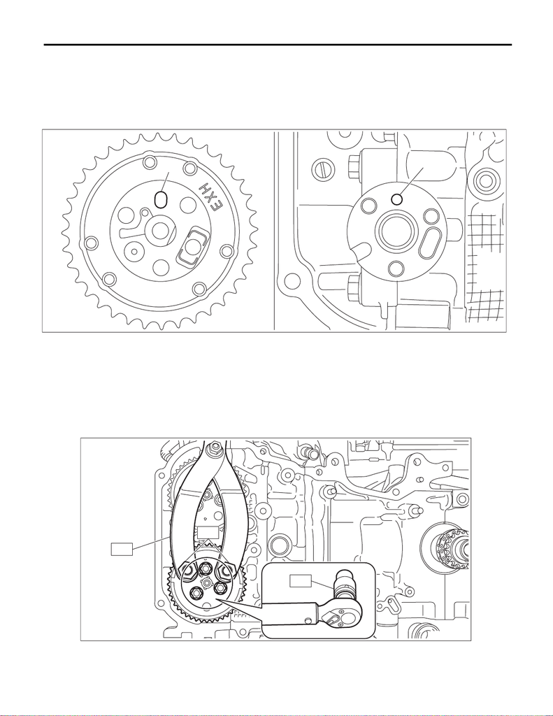

ME(w/o STI)-146

Cam Sprocket

MECHANICAL

• Exhaust cam sprocket RH

1) Install the exhaust cam sprocket RH by aligning the knock hole (A) of exhaust cam sprocket RH and the

knock pin (B) of exhaust camshaft RH.

NOTE:

Before installation, check that there is no foreign matter on the exhaust cam sprocket RH and exhaust cam-

shaft RH.

2) Hold the exhaust cam sprocket RH using ST1 and ST2, and install the bolts using ST3.

CAUTION:

Perform the operation carefully since the ST comes off easily.

ST1 18355AA000 PULLEY WRENCH

ST2 18334AA020 PULLEY WRENCH PIN SET

ST3 18270KA010 SOCKET

Tightening torque:

18 N·m (1.8 kgf-m, 13.3 ft-lb)

3) Install the timing chain RH. <Ref. to ME(w/o STI)-133, TIMING CHAIN RH, INSTALLATION, Timing Chain

Assembly.>

4) Install the chain cover. <Ref. to ME(w/o STI)-101, INSTALLATION, Chain Cover.>

ME-05574

(B)

(A)

ME-07983

ST2

ST1

ST3

15WRX_STI_US_EN.book 146 ページ ２０１５年２月１３日 金曜日 午前１１時２０分

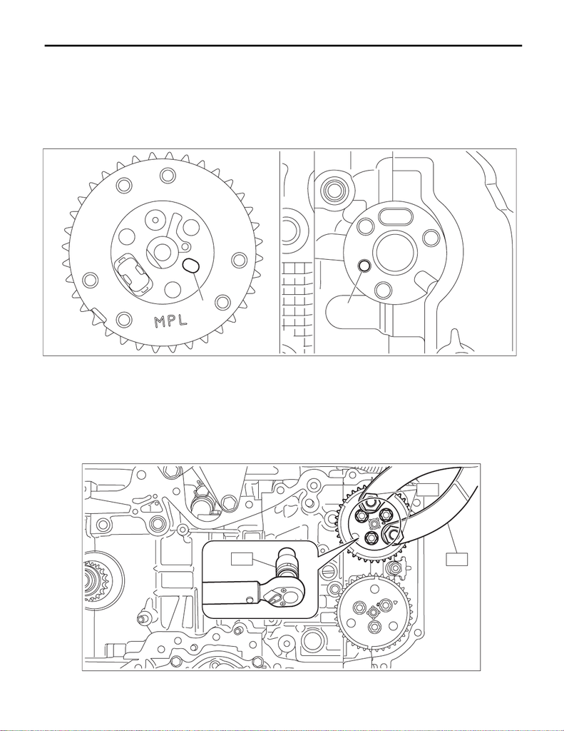

ME(w/o STI)-147

Cam Sprocket

MECHANICAL

2. CAM SPROCKET LH

• Intake cam sprocket LH

1) Install the intake cam sprocket LH by aligning the knock hole (A) of intake cam sprocket LH and the knock

pin (B) of intake camshaft LH.

NOTE:

Before installation, check that there is no foreign matter on the intake cam sprocket LH and intake camshaft

LH.

2) Hold the intake cam sprocket LH using the ST1 and ST2, and install the bolts using the ST3.

CAUTION:

Perform the operation carefully since the ST comes off easily.

ST1 18355AA000 PULLEY WRENCH

ST2 18334AA020 PULLEY WRENCH PIN SET

ST3 18270KA010 SOCKET

Tightening torque:

18 N·m (1.8 kgf-m, 13.3 ft-lb)

ME-06668

(B)

(A)

ME-07984

ST1

ST2

ST3

15WRX_STI_US_EN.book 147 ページ ２０１５年２月１３日 金曜日 午前１１時２０分

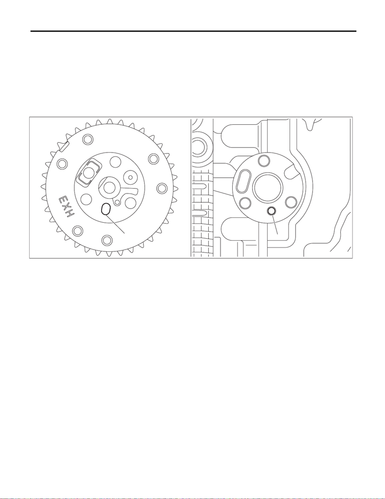

ME(w/o STI)-148

Cam Sprocket

MECHANICAL

3) Install timing chain LH. <Ref. to ME(w/o STI)-124, TIMING CHAIN LH, INSTALLATION, Timing Chain As-

sembly.>

4) Install the chain cover. <Ref. to ME(w/o STI)-101, INSTALLATION, Chain Cover.>

• Exhaust cam sprocket LH

1) Install the exhaust cam sprocket LH by aligning the knock hole (A) of exhaust cam sprocket LH and the

knock pin (B) of exhaust camshaft LH.

NOTE:

Before installation, check that there is no foreign matter on the exhaust cam sprocket LH and exhaust cam-

shaft LH.

ME-06670

(A)

(B)

15WRX_STI_US_EN.book 148 ページ ２０１５年２月１３日 金曜日 午前１１時２０分

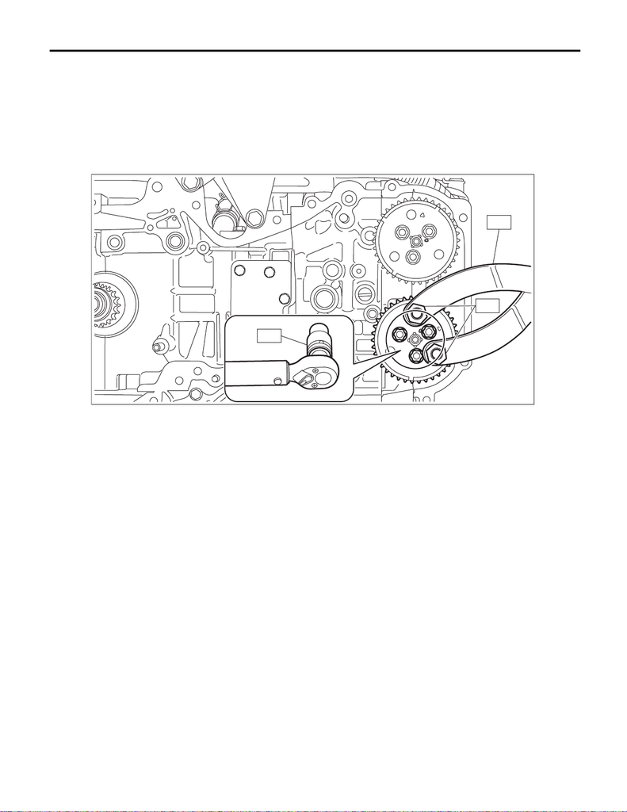

ME(w/o STI)-149

Cam Sprocket

MECHANICAL

2) Hold the exhaust cam sprocket LH using the ST1 and ST2, and install the bolts using the ST3.

CAUTION:

Perform the operation carefully since the ST comes off easily.

ST1 18355AA000 PULLEY WRENCH

ST2 18334AA020 PULLEY WRENCH PIN SET

ST3 18270KA010 SOCKET

Tightening torque:

18 N·m (1.8 kgf-m, 13.3 ft-lb)

3) Install timing chain LH. <Ref. to ME(w/o STI)-124, TIMING CHAIN LH, INSTALLATION, Timing Chain As-

sembly.>

4) Install the chain cover. <Ref. to ME(w/o STI)-101, INSTALLATION, Chain Cover.>

C: INSPECTION

Check the cam sprocket teeth for abnormal wear and scratches.

ME-07985

ST1

ST2

ST3

15WRX_STI_US_EN.book 149 ページ ２０１５年２月１３日 金曜日 午前１１時２０分